# Bank Campaign Analysis

Kathirmani Sukumar

September 5, 2017

### Load data

```r
library(dplyr)
library(ggplot2)
library(reshape)
library(knitr)
bank = read.csv('c:/Users/Kathirmani/Desktop/manipal_eda/bank/bank-full.csv', sep = ';')
dim(bank)
```

```
## [1] 45211    17
```

## EDA Process

- Check for number of rows and columns
- Understand what each row is for
- Calculate the percentage of nulls in each column
- Missing value treatment
- Identify the type of each column
- Groups, Metrics, Dates, Text, Location
- Derive new columns
- Date
  - Day, month, year, day of week, week of the year, quarter etc
- Numerical column
  - Bins (Age group from age, financial status from bank balance etc)
  - Thresholds (Centuries, fifties from runs etc)
- And classifiy the new derived columns
- For each dimension column
  - Group by and calculate the count and percentage
  - See if any sub group has more than 80%. If so think if we should remove that column from data
- For each numerical column
  - Draw histogram
  - Look for distribution
  - Skewness
  - Outliers
  - Draw box plot
  - Identify outliers
- Pick one dimension and one numerical column
  - Group by dimension and take average of the numerical column
  - Compute t-test or ANNOVA
- Pick two dimensions column
  - Crosstab analysis
  - Chi-square test for statistical validation
- Pick two numerical columns
  - Plot scatter plot
  - Look at trending, outliers and visual grouping
- Multivariate analysis

### Data availability

```r
num.na = colSums(!is.na(bank))*100/nrow(bank)
num.na
```

```
##       age       job   marital education   default   balance   housing
##       100       100       100       100       100       100       100
##      loan   contact       day     month  duration  campaign     pdays
##       100       100       100       100       100       100       100
##  previous  poutcome         y
##       100       100       100
```

### Frequency distribution of each dimension column

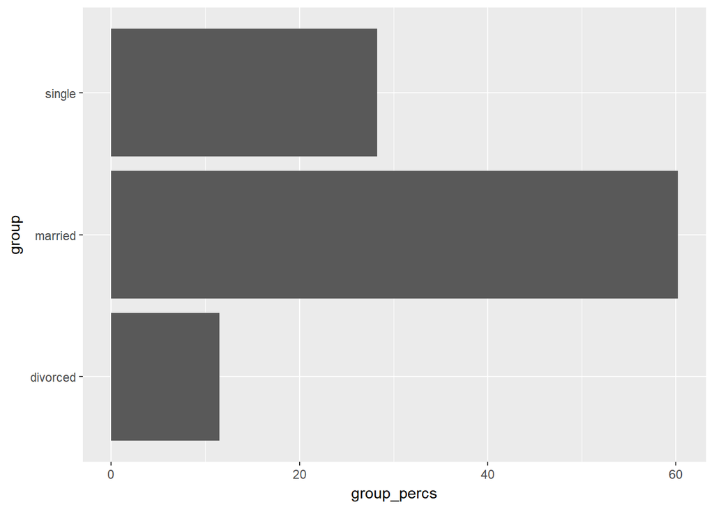

```r
group_name = 'marital'
education_counts = bank %>% group_by(group=get(group_name)) %>% summarise(group_percs=n()*100/nrow(bank))
ggplot(education_counts,aes(x=group,y=group_percs))+ geom_bar(stat='identity') + coord_flip()
```

## Frequency distribution of each numerical column

### Box plot

- To identify outliers
- To look at quartiles

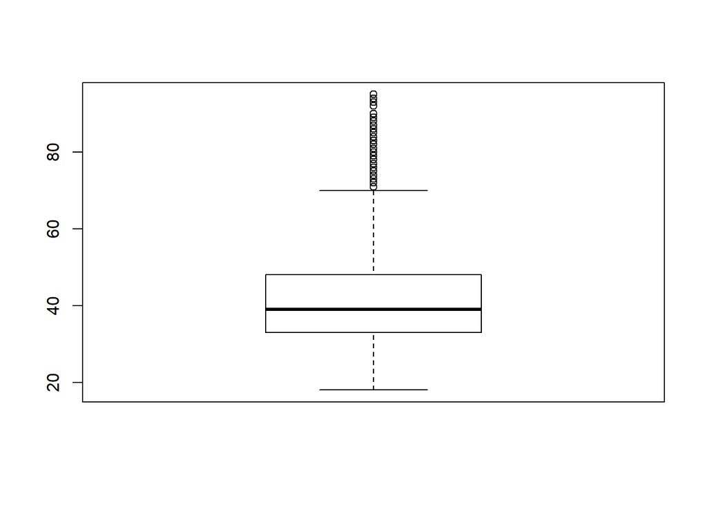

```r
boxplot(bank$age)
```

```r
# sum(bank$age>70.5) / nrow(bank) * 100

rows_above_70 = filter(bank, age>70.5)
age_outlier_perc = nrow(rows_above_70) / nrow(bank) * 100
age_outlier_perc
```

```
## [1] 1.077171
```

### Histogram

- To get an idean about underlying distribution
- To check if data is skewed
- To check for standard deviation/Variation
- To detect outliers

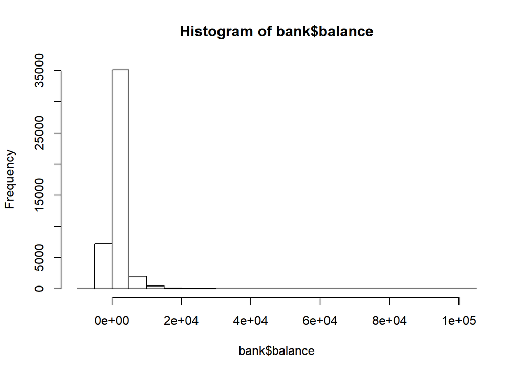

```r
hist(bank$balance)
```

```r
summary(bank$balance)
```

```
##    Min. 1st Qu.  Median    Mean 3rd Qu.    Max.
##   -8019      72     448    1362    1428  102127
```

```r
quantile(bank$balance)
```

```
##     0%    25%    50%    75%   100%
##  -8019     72    448   1428 102127
```

### Box plot

- To identify outliers
- To look at quartiles

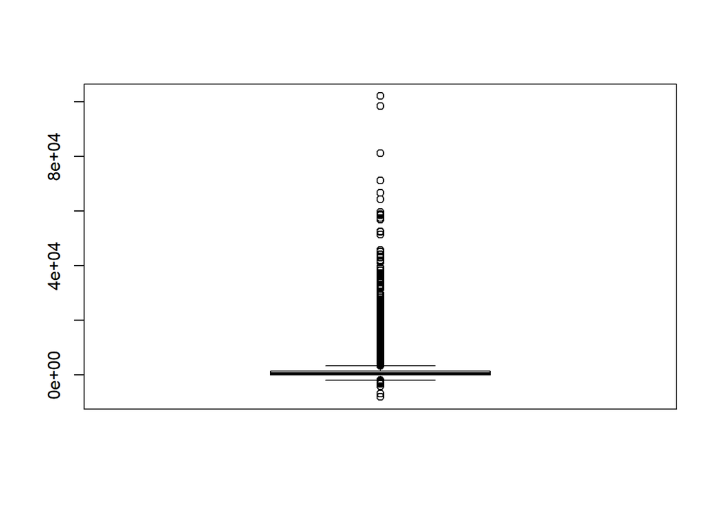

```r
boxplot(bank$balance)
```

```r
iqr = 1428 - 72
outlier_upper_range = 1428 + 1.5 * iqr
outlier_perc = sum(bank$balance > outlier_upper_range) / nrow(bank) * 100
outlier_perc
```

```
## [1] 10.42224
```

### No. of campaigns across different months

```r
f= bank %>% group_by(month) %>% summarise(s=sum(campaign)) %>% arrange(-s)
head(f,2)
```

```
## # A tibble: 2 x 2
##    month     s
##   <fctr> <int>
## 1    may 33693
## 2    aug 24534
```

```r
f= bank %>% group_by(month) %>% summarise(count=n()/nrow(bank)*100) %>% arrange(-count)
kable(f)
```

[output not shown]

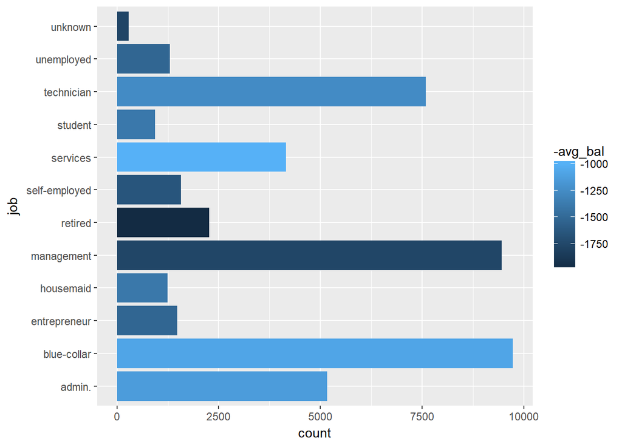

```r
job_balance= bank %>% group_by(job) %>% summarise(avg_bal=mean(balance), count=n()) %>% arrange(-count)
ggplot(job_balance,aes(x=job,y=count,fill=-avg_bal))+geom_bar(stat="identity") + coord_flip()
```

### Response rate by job category

```r
bank=mutate(bank,responded=if_else(y=='yes',1,0))
sum(bank$responded)
```

```
## [1] 5289
```

```r
response_job = bank %>% group_by(job) %>% summarise( response_rate=mean(responded)*100) %>% arrange(-response_rate)
kable(response_job)
```

| job | response_rate |
| --- | --- |
| student | 28.678038 |
| retired | 22.791519 |
| unemployed | 15.502686 |
| management | 13.755551 |
| admin. | 12.202669 |
| self-employed | 11.842939 |
| unknown | 11.805556 |
| technician | 11.056996 |
| services | 8.883004 |
| housemaid | 8.790323 |
| entrepreneur | 8.271688 |
| blue-collar | 7.274969 |

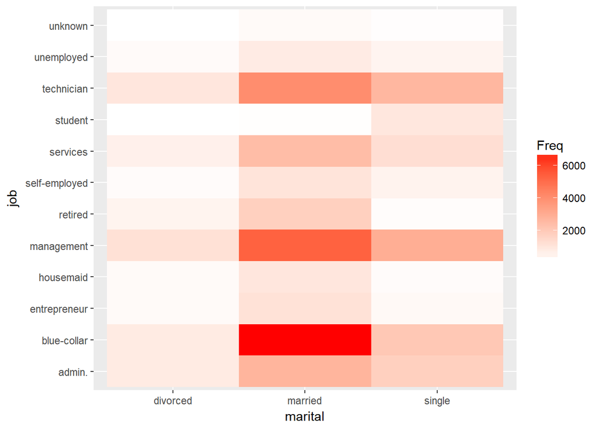

```r
summary = table(bank$job, bank$marital)

# 1. Convert summary to data frame
summary = as.data.frame(summary)

# 2. Rename columns
names(summary) = c('job', 'marital', 'Freq')

# 3. Pass it to ggplot and use geom_tile() to get heatmap
ggplot(summary, aes(x=marital, y=job, fill=Freq)) + geom_tile() + scale_fill_gradient(low="white", high="red")
```